# Adding levels of randomness

Peter Ralph

15 January 2018 – Advanced Biological Statistics

## Outline

1. Credible intervals
   - applied to the Beta-Binomial example
2. Hierarchical coins
3. Introduction to MCMC
4. Stan

# Reporting uncertainty

## How do we communicate results?

If we want a *point estimate*:

1. posterior mean,
2. posterior median, or
3. maximum *a posteriori* estimate (“MAP”: highest posterior density).

These all convey “where the posterior distribution is”, more or less.

What about uncertainty?

## Credible region

**Definition:** A 95% *credible region* is a portion of parameter space having a total of 95% of the *posterior probability*.

(same with other numbers for “95%”)

## Interpretation #1

If we construct a 95% credible interval for $\theta$ for each of many datasets; *and* the coin in each dataset has $\theta$ drawn independently from the prior, *then* the true $\theta$ will fall in its credible interval for 95% of the datasets.

## Interpretation #2

If we construct a 95% credible interval for $\theta$ with a dataset, and the distribution of the coin’s true $\theta$ across many parallel universes is given by the prior, then the true $\theta$ will be in the credible interval in 95% of those universes.

## Interpretation #3

Given my prior beliefs (prior distribution), the posterior distribution is the most rational${}^*$ way to update my beliefs to account for the data.

${}^*$ if you do this many times you will be wrong least often

${}^*$ **or** you will be wrong in the fewest possible universes

## But which credible interval?

**Definition:** The “95% highest density interval” is the 95% credible interval with the highest posterior probability density at each point.

((back to the simple example))

# Hierarchical coins

## Motivating problem: more coins

Suppose now we have data from $n$ different coins from the same source *(or, sequences, or …)*

Suppose now we have data from $n$ different coins from the same source. We don’t assume they have the *same* $\theta$, but don’t know what it’s distribution is, so try to *learn* it.

$$\begin{aligned}
Z_i &\sim \Binom(N_i, \theta_i) \\
\theta_i &\sim \Beta(\text{mode}=\omega, \text{conc}=\kappa) \\
\omega &\sim \Beta(A, B) \\
\kappa &\sim \Gam(S, R)
\end{aligned}$$

*note:* The “mode” and “concentration” are related to the shape parameters by: $\alpha = \omega (\kappa - 2) + 1$ and $\beta = (1 - \omega) (\kappa - 2) + 1$.

## Binomial versus Beta-Binomial

What is different between:

In which case does knowing the outcome of one coin give you information about the likely behavior of other coins?

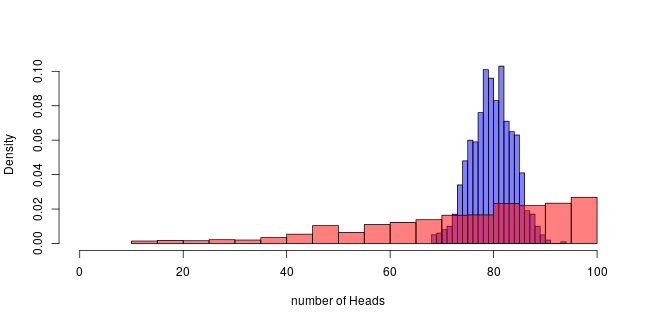

```r
ncoins <- 1000
nflips <- 100
theta1 <- rbeta(1,3,1)
binom_Z <- rbinom(ncoins, size=nflips, prob=theta1)
theta2 <- rbeta(ncoins,3,1)
bb_Z <- rbinom(ncoins, size=nflips, prob=theta2)
hist(binom_Z, breaks=30, col=adjustcolor("blue", 0.5), main='', xlim=c(0,nflips), freq=FALSE, xlab='number of Heads')
hist(bb_Z, breaks=30, col=adjustcolor("red", 0.5), add=TRUE, freq=FALSE)
```

## A problem

$$\begin{aligned}
Z_i &\sim \Binom(N_i, \theta_i) \\
\theta_i &\sim \Beta(\text{mode}=\omega, \text{conc}=\kappa) \\
\omega &\sim \Beta(A, B) \\
\kappa &\sim \Gam(S, R)
\end{aligned}$$

**Goal:** find the posterior distribution of $\omega$, $\kappa$, and $\theta_1, \ldots, \theta_n$.

**Problem:** we don’t have a nice mathematical expression for this posterior distribution.

# Markov Chain Monte Carlo

## When you can’t do the integrals: MCMC

**Goal:** Given:

- a model with parameters $\theta$,
- a prior distribution $p(\theta)$ on $\theta$, and
- data, $D$,

“find”/ask questions of the posterior distribution on $\theta$,

$$\begin{aligned}
p(\theta \given D) = \frac{ p(D \given \theta) p(\theta) }{ p(D) } .
\end{aligned}$$

**Problem:** usually we can’t write down an expression for this (because of the “$p(D)$”).

**Solution:** we’ll make up a way to *draw random samples* from it.

**Toy example:**

*(return to beta-binomial coin example)*

Do we think that $\theta < 0.5$?

*(before:)*

```r
pbeta(0.5, post_a, post_b)
```

*(now:)*

```r
mean(rbeta(1e6, post_a, post_b) < 0.5)
```

## How? Markov chain Monte Carlo!

i.e., “random-walk-based stochastic integration”

**Example:** Gibbs sampling for uniform distribution on a region. *(picture)*

## Overview of MCMC

Produces a random sequence of samples $\theta_1, \theta_2, \ldots, \theta_N$.

0. Begin somewhere (at $\theta_1$).

At each step, starting at $\theta_k$:

1. **Propose** a new location (nearby?): $\theta_k'$
2. Decide whether to **accept** it.
   - if so: set $\theta_{k+1} \leftarrow \theta_k'$
   - if not: set $\theta_{k+1} \leftarrow \theta_k$
3. Set $k \leftarrow k+1$; if $k=N$ then stop.

The magic comes from doing *proposals* and *acceptance* so that the $\theta$’s are samples from the distribution we want.

## Key concepts

- Rules are chosen so that $p(\theta \given D)$ is the *stationary* distribution (long-run average!) of the random walk (the “Markov chain”).
- The chain must *mix* fast enough so the distribution of visited states *converges* to $p(\theta \given D)$.
- Because of *autocorrelation*, $(\theta_1, \theta_2, \ldots, \theta_N)$ are not $N$ independent samples: they are roughly equivalent to $N_\text{eff} < N$ independent samples.
- For better *mixing*, acceptance probabilities should not be too high or too low.
- Starting *several chains* far apart can help diagnose failure to mix: Gelman’s $r$ (“shrink”) quantifies how different they are.

## On your feet

Three people, with randomness provided by others:

1. Pick a random $\{N,S,E,W\}$.
2. Take a step in that direction,
   - *unless* you’d run into a wall or a table.

**Question:** What distribution will this sample from?

Do this for 10 iterations. Have the *chains mixed*?

**Now:**

1. Pick a random $\{N,S,E,W\}$.
2. Take a $1+\Poisson(5)$ number of steps in that direction,
   - *unless* you’d run into a wall or a table.

Does it mix faster?

Would $1 + \Poisson(50)$ steps be better?

## How it works

Imagine the walkers are on a hill, and:

What would *this* do?

Thanks to *Metropolis-Hastings*, if “elevation” is $p(\theta \given D)$, then setting $p = p(\theta' \given D) / p(\theta \given D)$ makes the stationary distribution $p(\theta \given D)$.

# MC Stan

## “Quick and easy” MCMC: Stan

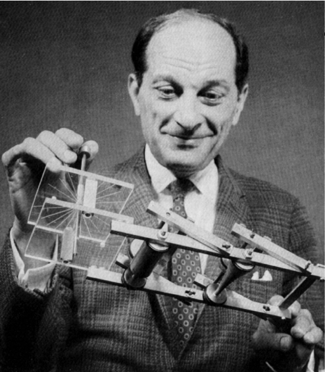

Stanislaw Ulam

## The skeletal Stan program

```
data {
    // stuff you input
}
transformed data {
    // stuff that's calculated from the data (just once, at the start)
}
parameters {
    // stuff you want to learn the posterior distribution of
}
transformed parameters {
    // stuff that's calculated from the parameters (at every step)
}
model {
    // the action!
}
generated quantities {
    // stuff you want computed also along the way
}
```